# Machine Learning Project

PdN

Friday, May 22, 2015

# Background

Using devices such as Jawbone Up, Nike FuelBand, and Fitbit it is now possible to collect a large amount of data about personal activity relatively inexpensively. These type of devices are part of the quantified self movement - a group of enthusiasts who take measurements about themselves regularly to improve their health, to find patterns in their behavior, or because they are tech geeks. One thing that people regularly do is quantify how much of a particular activity they do, but they rarely quantify how well they do it. In this project, your goal will be to use data from accelerometers on the belt, forearm, arm, and dumbell of 6 participants. They were asked to perform barbell lifts correctly and incorrectly in 5 different ways. More information is available from the website here: http://groupware.les.inf.puc-rio.br/har (see the section on the Weight Lifting Exercise Dataset).

## Setting environment

```r
rm(list = ls())

# Libraries

library(ggplot2)
library(caret)
```

## Getting data from the net

The data for this project come from this source: http://groupware.les.inf.puc-rio.br/har.

```r
# The training data for this project are available here:

training_url <- "https://d396qusza40orc.cloudfront.net/predmachlearn/pml-training.csv"
training_local <- "pml-training.csv"

# The test data are available here:

testing_url <- "https://d396qusza40orc.cloudfront.net/predmachlearn/pml-testing.csv"
testing_local <- "pml-testing.csv"

if (!file.exists(training_local)) {
    download.file(training_url,
                  destfile = training_local)
}

if (!file.exists(testing_local)) {
    download.file(testing_url,
                  destfile = testing_local)
}

# Reading training and testing files

testing  <- read.csv(testing_local, header=TRUE, sep= ",",na.strings=c("NA","", "#DIV/0!"))
training <- read.csv(training_local, header=TRUE, sep= ",",na.strings=c("NA","", "#DIV/0!"))
```

## Some data cleaning and preparation

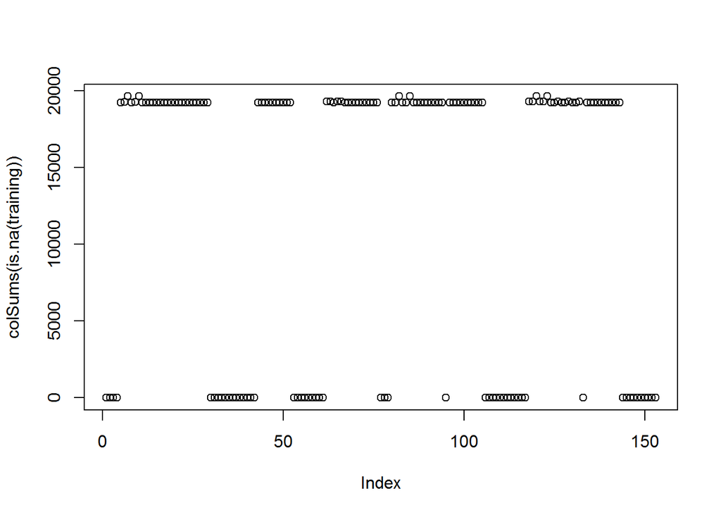

```r
# By looking at the variables, we can assume that user_name, the various timestamps and *_window can be removed
testing <- testing[, -c(1:7)]
training <- training[, -c(1:7)]

# Other data cleaning
# There are many NAs, we can remove the variables with too many NAs, as they cannot contribute to the prediction
plot(colSums(is.na(training)))
```

```r
# We remove variables that has more than 90% NAs
col2remove <- which(as.numeric(colSums(is.na(training))) > 0.9*nrow(training))
training <- training[, - col2remove]
# Using the exact same criteria (based on training) for testing
testing <- testing[, - col2remove]
```

Partitioning the supplied training data into training and validation (testing data being already provided)

```r
set.seed(1962)
in_train <- createDataPartition(training$classe, p=0.70, list=FALSE)
training <- training[in_train,]
validation <- training[-in_train,]
```

Reducing the number of variables using PCA

```r
training_pca=preProcess(training[,-53],method="pca",na.remove = TRUE, thresh=.99)
pca_training=predict(training_pca,training[,-53])

pca_validation=predict(training_pca,validation[,-53])
```

The number of variables reduces to 36

With the reduced set of variables a model is derived, using random forest algorithm

```r
if (!exists("rfFit")) {
rfFit <- train(training$classe ~ ., method = "rf", data = pca_training)
}
```

## Cross validation with the validation subset

```r
xvalid <- confusionMatrix(validation$classe, predict(rfFit, pca_validation))
```

Summary of the accuracy of the mode

```r
print(xvalid)
```

```
## Confusion Matrix and Statistics
##
##           Reference
## Prediction    A    B    C    D    E
##          A 1184    0    0    0    0
##          B    0  801    0    0    0
##          C    0    0  707    0    0
##          D    0    0    0  669    0
##          E    0    0    0    0  759
##
## Overall Statistics
##
##                Accuracy : 1
##                  95% CI : (0.9991, 1)
##     No Information Rate : 0.2874
##     P-Value [Acc > NIR] : < 2.2e-16
##
##                   Kappa : 1
##  Mcnemar's Test P-Value : NA
##
## Statistics by Class:
##
##                      Class: A Class: B Class: C Class: D Class: E
## Sensitivity            1.0000   1.0000   1.0000   1.0000   1.0000
## Specificity            1.0000   1.0000   1.0000   1.0000   1.0000
## Pos Pred Value         1.0000   1.0000   1.0000   1.0000   1.0000
## Neg Pred Value         1.0000   1.0000   1.0000   1.0000   1.0000
## Prevalence             0.2874   0.1944   0.1716   0.1624   0.1842
## Detection Rate         0.2874   0.1944   0.1716   0.1624   0.1842
## Detection Prevalence   0.2874   0.1944   0.1716   0.1624   0.1842
## Balanced Accuracy      1.0000   1.0000   1.0000   1.0000   1.0000
```

## Final test with the provided test set

```r
pca_testing=predict(training_pca,testing[,-53])
test_result <- predict(rfFit, pca_testing)
```

Vector submitted for grading (20/20)

```r
print(test_result)
```

```
##  [1] B A B A A E D B A A B C B A E E A B B B
## Levels: A B C D E
```

## Reference

Velloso, E.; Bulling, A.; Gellersen, H.; Ugulino, W.; Fuks, H. Qualitative Activity Recognition of Weight Lifting Exercises. Proceedings of 4th International Conference in Cooperation with SIGCHI (Augmented Human ’13) . Stuttgart, Germany: ACM SIGCHI, 2013.